# Machine Learning for Computational Economics

Module 04: Fundamentals of Machine Learning  
EDHEC Business School

Dejanir Silva

Purdue University

January 2026

## Introduction

In this module, we introduce the fundamental concepts of machine learning.

- Our goal is not to provide a comprehensive review of the field
  - See, e.g., Hastie, Tibshirani, and Friedman (2009), Goodfellow, Bengio, and Courville (2016), and Prince (2023) for excellent reviews.
- But rather to develop the core tools needed to study high-dimensional economic models.

We proceed in three steps.

- We show how to represent functions using **neural networks**.
- We explain how to estimate their parameters using **stochastic gradient descent**.
- We describe how **automatic differentiation** enables efficient computation of the gradients.

The module is organized as follows:

1. Supervised Learning and Neural Networks
2. Gradient Descent and Its Variants
3. Automatic Differentiation and Backpropagation

# I. Supervised Learning

## Supervised Learning

**Supervised learning** concerns the task of inferring a mapping from inputs to outputs using labeled data.

- It seeks to learn a function $f$ that maps inputs $\mathbf{x} \in \mathbb{R}^d$ to outputs $\mathbf{y} \in \mathbb{R}^p$, given a dataset of labeled pairs $\{(\mathbf{x}_i, \mathbf{y}_i)\}_{i=1}^I$.
- In essence, this is a *regression problem*, but one that often involves extremely large input spaces and complex nonlinear dependencies.

**Example: Image classification.**

- The ImageNet dataset contains over 15 million labeled images spanning more than 22,000 categories.
- Each image is a $224\times224\times3$ array of pixels, where each pixel takes values between 0 and 255.

A linear model could, in principle, be used to predict the category of an image.

- However, such a model would treat each pixel *independently*: marginal effects are unrelated to neighboring pixels.
- Images, by contrast, contain strong spatial structure and nonlinear relationships between pixels across channels.

**AlexNet**

In groundbreaking work, Krizhevsky, Sutskever, and Hinton (2012)—widely known as AlexNet—introduced a deep neural network architecture that achieved dramatic improvements in classification accuracy on ImageNet.

- Their model had eight layers and over 60 million parameters, exceptionally large at the time.
- It demonstrated that deep neural networks could solve complex visual tasks at scale.

## ImageNet Image and its RGB Channels

[figure not shown]

## Linear Regression

To illustrate the key concepts in supervised learning, it is useful to start with a familiar model: **linear regression**.

- Suppose we are given a dataset of $I$ observations of the input $\mathbf{x}_i \in \mathbb{R}^d$ and output $y_i \in \mathbb{R}$ for $i = 1, \ldots, I$.
- Given the input $\mathbf{x}_i$, the model prediction $\hat{y}_i$ is given by the function $f(\mathbf{x}_i, \mathbf{\theta})$, where $\mathbf{\theta} \in \mathbb{R}^d$ is a vector of parameters.
  $$f(\mathbf{x}_i, \mathbf{\theta})
  = \color{#0072b2}{\underbrace{\mathbf{w}^{\top}}_{\text{weights}}}\mathbf{x}_i
  + \color{#d55e00}{\underbrace{b}_{\text{bias}}}$$
  where $\mathbf{\theta} = (\mathbf{w}^{\top}, b)^{\top}$.

[figure not shown]

The function $f(\mathbf{x}_i, \mathbf{\theta})$ defines a family of linear functions

- We obtain different functions by varying the parameters $\mathbf{\theta}$.

Our goal is to find the parameter values that *best* fit the data.

- To do this, we define a loss function that measures model fit:
  $$\mathcal{L}(\mathbf{\theta}) = \frac{1}{2I} \sum_{i=1}^I (y_i - f(\mathbf{x}_i, \mathbf{\theta}))^2.$$
  This is the **mean squared error** (MSE) loss function.

## The Least Squares Estimator

Our goal is to find the parameters that *minimize* the loss function.

- In the linear regression case, we can solve for the optimal parameters in closed form.
- We need to set the **gradient** of the loss function to zero:
  $$\nabla \mathcal{L}(\mathbf{\theta}) =
  \begin{bmatrix}
  \frac{\partial \mathcal{L}}{\partial \mathbf{w}} \\
  \frac{\partial \mathcal{L}}{\partial b}
  \end{bmatrix}
  = \frac{1}{I}\mathbf{X}^{\top} (\mathbf{X} \mathbf{\theta} - \mathbf{y}) = \mathbf{0}$$
  where
  $$\mathbf{X} = \begin{bmatrix}
  \mathbf{x}_1^{\top} & 1 \\
  \mathbf{x}_2^{\top} & 1 \\
  \vdots & \vdots \\
  \mathbf{x}_I^{\top} & 1
  \end{bmatrix} \in \mathbb{R}^{I \times d},
  \qquad
  \mathbf{y} =
  \begin{bmatrix}
  y_1 \\ y_2 \\ \vdots \\ y_I
  \end{bmatrix} \in \mathbb{R}^I.$$

Solving the **normal equations** yields the least squares estimator:
$$\hat{\mathbf{\theta}} = (\mathbf{X}^{\top} \mathbf{X})^{-1} \mathbf{X}^{\top} \mathbf{y}.$$

**Gradient**

We denote the **gradient** of a function $f(\mathbf{x})\in \mathbb{R}$ with respect to $\mathbf{x}\in \mathbb{R}^d$ as $\nabla f(\mathbf{x})\in \mathbb{R}^d$.

- The gradient is a column vector, so its differential is written as $d f(\mathbf{x}) = \nabla f(\mathbf{x})^{\top} d\mathbf{x}$.

## Gradient Descent

In general, we cannot solve for the parameters in closed form.

- In this case, we need to use an iterative method to find the parameters, such as **gradient descent**.

Starting from an initial guess $\mathbf{\theta}^{(0)}$, gradient descent updates $\mathbf{\theta}$ in the direction *opposite* to the gradient of the loss function.

- To see why, note that the change in the loss function is approximately given by:
  $$\mathcal{L}(\mathbf{\theta} + \Delta \mathbf{\theta}) - \mathcal{L}(\mathbf{\theta})
  \approx \nabla \mathcal{L}(\mathbf{\theta})^{\top} \Delta \mathbf{\theta},
  \qquad \qquad
  |\nabla \mathcal{L}(\mathbf{\theta})^{\top} \Delta \mathbf{\theta}|
  \leq \|\nabla \mathcal{L}(\mathbf{\theta})\|\,\|\Delta \mathbf{\theta}\|$$
- The largest reduction in the loss function is achieved when $\Delta \mathbf{\theta}$ is proportional to the negative gradient.

Given a learning rate $\eta$, the gradient descent update rule is:
$$\mathbf{\theta} \leftarrow \mathbf{\theta} - \eta \nabla \mathcal{L}(\mathbf{\theta})$$

**Computational cost**

The gradient of the loss function with respect to the parameters is given by:
$$\nabla \mathcal{L}(\mathbf{\theta})
= \frac{1}{I} \sum_{i=1}^I
\big(f(\mathbf{x}_i, \mathbf{\theta}) - y_i\big)\,
\nabla_{\mathbf{\theta}} f(\mathbf{x}_i, \mathbf{\theta}).$$
Each iteration of gradient descent therefore requires evaluating $\nabla_{\mathbf{\theta}} f(\mathbf{x}_i, \mathbf{\theta})$ for all $I$ observations.

- For large datasets, this can be computationally expensive

## Implementation of Gradient Descent

**Algorithm: Gradient Descent**

**Input:** Initial guess $\mathbf{\theta}^{(0)}$, learning rate $\eta$  
**Output:** Parameter estimate $\mathbf{\theta}$  
**Initialize:** $t \gets 0$

**Repeat** until $\|\nabla \mathcal{L}(\mathbf{\theta}^{(t)})\| < \epsilon$:

- **Parameter update:**  
  $\mathbf{\theta}^{(t+1)} \gets \mathbf{\theta}^{(t)} - \eta \nabla \mathcal{L}(\mathbf{\theta}^{(t)})$
- $t \gets t + 1$

**Return:** $\mathbf{\theta}^{(t)}$

```julia
function ls_grad_descent(y::AbstractVector{<:Real}, x::AbstractVector{<:Real}, θ₀::AbstractVector{<:Real};
    learning_rate::Real=0.01, max_iter::Integer=100, ε::Real = 1e-4)
    @assert length(x) == length(y)
    I = length(x)
    X = hcat(x, ones(I)) # design matrix
    ∇f(θ) = X' * (X * θ - y) / I # gradient
    w_path, b_path =Float64[θ₀[1]], Float64[θ₀[2]] # initial values
    for _ in 1:max_iter
        g = ∇f([w_path[end], b_path[end]])
        push!(w_path, w_path[end] - learning_rate * g[1])
        push!(b_path, b_path[end] - learning_rate * g[2])
        if norm(g) < ε
            break
        end
    end
    return (;w = w_path, b = b_path)
end
```

## Loss Surface

The **loss surface** shows the loss for different parameter values.

[figure not shown]

We can visualize the loss surface as a *heatmap*.

- The minimum of the loss surface is the parameter values that best fit the data.
- This corresponds to the darkest region in the heatmap.

The animation shows the gradient descent path being traced

- The yellow path shows how the algorithm moves toward the minimum.
- The red dot marks the true parameter values used to simulate the data.
- The algorithm converges to the minimum of the loss surface.

## Training and Testing

In the discussion above, we used all available data to estimate the parameters.

- In practice, we typically split the data into a **training set** and a **test set**.
- The training set is used to estimate the parameters, the test set is used to evaluate how well the model fits new data.

Consider data generated by a noisy version of the *Runge function*:
$$y_i = \frac{1}{1+25 z_i^2} + \epsilon_i,
\qquad \epsilon_i \sim \text{i.i.d. with } \mathbb{E}[\epsilon_i]=0,$$
with $z_i \in [-1,1]$.

Consider a polynomial regression with regressors:
$$\mathbf{x}_i = [z_i, z_i^2, \ldots, z_i^{d-1}]$$

As the degree $d$ increases, the model becomes more flexible.

[figure not shown]

When $d = I$, the model reaches the *interpolation threshold*.

- But high-degree polynomial interpolants of the Runge function oscillate violently.
- The model performs poorly on the test set for high $d$.

The figure shows the training loss declines steadily as $d$ increases

- But the test loss eventually rises: this is the hallmark of **overfitting**

# II. Neural Networks

## Shallow Neural Networks

We now move from linear to nonlinear models by introducing the **shallow neural network** (SNN).

- An SNN can be viewed as a generalization of the linear regression model
- A series of intermediate transformations combines a linear function with a nonlinear activation.

**Hidden units**: a nonlinear transformations of the inputs.
$$h_j(\mathbf{x}, \mathbf{\theta}_j) = \sigma(\mathbf{w}_j^{\top} \mathbf{x} + b_j), \qquad j = 0, \ldots, n-1$$
where $\sigma$ is an activation function, $\mathbf{\theta}_j = (\mathbf{w}_j^{\top}, b_j)^{\top}$.

The **SNN** can be written as:
$$f(\mathbf{x}, \mathbf{\theta}) = \mathbf{w}_n^{\top} \mathbf{h}(\mathbf{x}, \mathbf{\theta}) + b_n,$$
where $\mathbf{\theta} = (\mathbf{\theta}_0^{\top}, \ldots, \mathbf{\theta}_{n}^{\top})^{\top}$ and $\mathbf{\theta}_n = (\mathbf{w}_n^{\top}, b_n)^{\top}$.

[figure not shown]

The **rectified linear unit (ReLU)**:
$$\sigma(x) = \max(0, x).$$

This is the mostly used activation function in machine learning.

- We will often focus on the ReLU.

[figure not shown]

The **Gaussian Error Linear Unit (GELU)**:
$$\sigma(x) = x \Phi(x),$$
where $\Phi(x)$ is the standard normal cdf.

- It has been shown to improve performance in many applications.

[figure not shown]

The **hyperbolic tangent (tanh)**:
$$\sigma(x) = \frac{1 - e^{-2x}}{1 + e^{-2x}}.$$
It is historically popular in recurrent networks.

- It provides smooth, bounded outputs between -1 and 1.

[figure not shown]

The **Sigmoid Linear Unit (SiLU)**:
$$\sigma(x) = \frac{x}{1 + e^{-x}}.$$
Also known as Swish.

- SiLU yields smooth gradients even for negative inputs.

## SNNs Architecture and Implementation

[figure not shown]

This figure illustrates the *architecture* of an SNN.

- Green nodes: **input layer**.
- Blue nodes: **hidden layer**.
- Orange node: **output layer**.

The hidden units are also known as *neurons*.

- A neural network is a collection of neurons.
- A *shallow* neural network has a single hidden layer.

```julia
function shallow_nn(x::AbstractVector{<:Real},
    W::AbstractMatrix{<:Real}, b::AbstractVector{<:Real},
    wₙ::AbstractVector{<:Real}, bₙ::Real; σ::Function = x->max(0,x))
    @assert size(W,2) == length(x)  # ncols of W = length of x
    @assert size(W,1) == length(wₙ) # nrows of W = length of wₙ
    @assert length(b) == size(W,1)  # biases for the hidden units
    return wₙ' * σ.(W * x .+ b)+ bₙ
end
# Convenience: scalar input (d = 1); w is the column of W
function shallow_nn(x::Real,
    w::AbstractVector{<:Real}, b::AbstractVector{<:Real},
    wₙ::AbstractVector{<:Real}, bₙ::Real; σ::Function = x->max(0,x))
    return shallow_nn([x], reshape(w,length(w),1), b, wₙ, bₙ, σ = σ)
end
```

## SNNs as Piecewise Linear Functions

To illustrate the structure of an SNN, consider a one-dimensional input $x_i \in [0,1]$ and a ReLU activation function.

- Assume that all hidden-unit weights are $w_j = 1$.

[figure not shown]

$$SNN: f(x_i, \theta) = \sum_{j=0}^{n-1} w_{n,j} \max(0, x_i - \hat{x}_j) + b_n,$$
where $\hat{x}_j \equiv - b_j$ is a convenient reparametrization of the biases.

Ordering the breakpoints as $0 = \hat{x}_0 < \cdots < \hat{x}_{n-1} < 1 \equiv \hat{x}_n$,
$$f(x_i, \theta) = f(\hat{x}_j, \theta) + w_{n,j}(x_i - \hat{x}_j),
\qquad x_i \in (\hat{x}_j, \hat{x}_{j+1}],$$
with $f(\hat{x}_0, \theta) = b_n$.

The function is piecewise linear, with the breakpoints $\hat{x}_j$ learned by the model.

- If we fix the breakpoints to be equally spaced, the network collapses to the locally linear interpolant from Module 3.
- Hence, an SNN can be interpreted as a *finite-difference method* with an **adaptive grid** that learns where to place the nodes.

## The Adaptive Choice of Breakpoints in Action

ReLU networks **adaptively** place their breakpoints in regions where the target function exhibits strong nonlinearity.

- To illustrate this, we fit a one–hidden–layer ReLU network to the density of a Beta distribution
- We choose parameters $\alpha=2$ and $\beta=10$, so the curvature is concentrated at low $x$ values.

[figure not shown]

**Model fit (15 hidden units)**

[figure not shown]

**Breakpoint histogram (15 hidden units)**

[figure not shown]

**Model fit (30 hidden units)**

[figure not shown]

**Breakpoint histogram (30 hidden units)**

[figure not shown]

**Model fit (100 hidden units)**

[figure not shown]

**Breakpoint histogram (100 hidden units)**

## The Universal Approximation Theorem

The piecewise–linear structure of an SNN enables it to approximate nonlinear functions.

- A natural question is: how expressive is this model? What class of functions can an SNN represent or approximate?

The **Universal Approximation Theorem** provides an answer.

**Universal Approximation Theorem**

Any continuous function on a compact subset of $\mathbb{R}^n$ can be approximated to arbitrary precision by a shallow neural network with any non-polynomial activation function.

**Proof:** See Cybenko (1989), Hornik (1991), and Leshno et al. (1993).

This result is closely related to the **Option Spanning Theorem** of Ross (1976)

- The result states that options portfolios can replicate any continuous payoff function.
- A ReLu SNN corresponds to a portfolio of call/put options.

The Universal Approximation Theorem establishes that shallow networks are theoretically sufficient

- But it does not imply that they are the most efficient way to approximate a function.
- Achieving high accuracy may require an exponentially large number of hidden units.
- We turn next to a richer class of models—**deep neural networks**—which can approximate complex functions more efficiently.

## Deep Neural Networks

A shallow neural network contains a single hidden layer between the input and output layers.

- **Deep neural networks** (DNNs) extend this architecture by stacking multiple hidden layers on top of each other.
- Each layer applies a linear transformation followed by a nonlinear activation.

Formally, let the $n_l$-dimensional vector of *hidden units* at layer $l$ be defined recursively as
$$\mathbf{h}_l(\mathbf{h}_{l-1}, \mathbf{\theta}_l) = \sigma(\mathbf{W}_l \mathbf{h}_{l-1} + \mathbf{b}_l), \qquad l = 1, \ldots, L-1,$$
where $\mathbf{\theta}_l = (\mathrm{vec}(\mathbf{W}_l)^{\top}, \mathbf{b}_l)^{\top}$ collects all parameters of layer $l$.

[figure not shown]

The first hidden layer operates directly on the input:
$$\mathbf{h}_0(\mathbf{x}, \mathbf{\theta}_0) = \sigma(\mathbf{W}_0 \mathbf{x} + \mathbf{b}_0),$$
and the output layer is given by
$$f(\mathbf{x}, \mathbf{\theta}) = \mathbf{W}_L \mathbf{h}_L + \mathbf{b}_L,$$
where $\mathbf{\theta} = (\mathbf{\theta}_0^{\top}, \ldots, \mathbf{\theta}_L^{\top})^{\top}$.

## Example: Composition of Functions

To understand the expressive power of deep neural networks, consider composing a simple shallow ReLU network with itself. Let
$$f_1(x) = 2\sigma(x) - 4\sigma(x - 0.5),$$
which produces a triangular function with a single kink at $x = 0.5$.

[figure not shown]

**Realized functions $f_k(x)$ for $k = 1, 2, 3$**

Composing this function with itself yields
$$f_k(x) = 2\sigma(f_{k-1}(x)) - 4\sigma(f_{k-1}(x) - 0.5).$$

We can represent $f_k(x)$ as a DNN with $k$ hidden layers:
$$\mathbf{h}_l(x) =
\begin{bmatrix}
\sigma(f_{l-1}(x)) \\
\sigma(f_{l-1}(x) - 0.5)
\end{bmatrix}.$$

The **number of parameters** required to represent $f_k(x)$ is:
$$4 + (k-1)\times 6 + 3 = 6k + 1.$$

The same function can also be represented as a shallow neural network

- It would require $2^k$ hidden units to capture all linear regions.
- Depth provides an **exponential gain** in expressive efficiency.

## Universal Approximation Theorem Revisited

Shallow networks are universal approximators:

- With enough width, they can approximate any continuous function on a compact domain.
- A complementary result establishes that **depth** alone can also achieve universal approximation.

**Universal Approximation Theorem Revisited**

For any Lebesgue-integrable function $f \in L^1(\mathbb{R}^n)$, there exists a ReLU deep neural network with width at most $n + 4$ in every hidden layer that approximates $f$ to arbitrary precision.

**Proof:** See Lu et al. (2017).

The width theorem shows that a single wide layer suffices for universal approximation

- The depth theorem shows that even networks of modest width can achieve the same expressive power when sufficiently deep.
- Depth provides an alternative, more parameter-efficient, route to functional richness.

## Julia Implementation

We now implement a deep neural network in Julia using `Lux.jl`.

- To start, we consider the function $f_1(x) = 2\sigma(x) - 4\sigma(x - 0.5)$ defined above.

The function `Chain` defines a sequence of layers.

- The `model` object stores the network structure and provides the parameter count.

```julia
using Lux
model = Chain(
    Dense(1 => 2, Lux.relu), # single input, two hidden units
    Dense(2 => 1, identity)  # two hidden units, one output
)
```

```
Chain(
    layer_1 = Dense(1 => 2, relu),                # 4 parameters
    layer_2 = Dense(2 => 1),                      # 3 parameters
)         # Total: 7 parameters,
          #        plus 0 states.
```

Next, we initialize the parameters of the network using a random number generator.

- `Lux` stores parameters explicitly as a **nested NamedTuple**.
- Each layer has its own sub-tuple, or **leaf**, containing its `weight` matrix and `bias` vector.

```julia
using Random
rng = Random.Xoshiro(123)
parameters, state = Lux.setup(rng, model)
parameters
```

```
(layer_1 = (weight = Float32[-3.1280737; 0.14697331;;], bias = Float32[-0.3321283, 0.17361343]), layer_2 = (weight = Float32[-1.1964471 0.95745337], bias = Float32[0.5698812]))
```

## Updating the Parameters

To reproduce the function $f_1(x)$, we can manually assign new values to the network parameters.

- `Lux` allows direct updates through a named tuple with the same structure as the initialized parameters:

```julia
parameters = (layer_1 = (weight = [1.0; 1.0;;], bias = [0.0, -0.5]),
              layer_2 = (weight = [2.0 -4.0], bias = [0.0]))
```

```
(layer_1 = (weight = [1.0; 1.0;;], bias = [0.0, -0.5]), layer_2 = (weight = [2.0 -4.0], bias = [0.0]))
```

We can now evaluate the network on a grid of inputs:

```julia
xgrid = collect(range(0.0, 1.0, length=9))
ygrid = model(xgrid', parameters, state)[1]
```

```
1×9 Matrix{Float64}:
 0.0  0.25  0.5  0.75  1.0  0.75  0.5  0.25  0.0
```

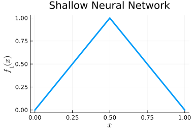

```julia
using Plots, LaTeXStrings
plot(xgrid, ygrid', line = 3, xlabel = L"x", ylabel = L"f_1(x)",
     title = "Shallow Neural Network", size = (400, 275), label = "")
```

## Defining a Deep Neural Network

To define a deeper network, we can stack multiple hidden layers.

```julia
model = Chain(
    Dense(1 => 2, Lux.relu),
    Dense(2 => 2, Lux.relu),
    Dense(2 => 1, identity)
)
```

```
Chain(
    layer_1 = Dense(1 => 2, relu),                # 4 parameters
    layer_2 = Dense(2 => 2, relu),                # 6 parameters
    layer_3 = Dense(2 => 1),                      # 3 parameters
)         # Total: 13 parameters,
          #        plus 0 states.
```

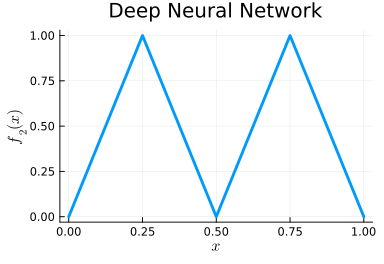

```julia
parameters, state = Lux.setup(rng, model)
parameters = (layer_1 = (weight = [1.0; 1.0;;], bias = [0.0, -0.5]),
              layer_2 = (weight = [2.0 -4.0; 2.0 -4.0], bias = [0.0, -0.5]),
              layer_3 = (weight = [2.0 -4.0], bias = [0.0]))
xgrid = collect(range(0.0, 1.0, length=9))
ygrid = model(xgrid', parameters, state)[1]'
plot(xgrid, ygrid, line = 3, xlabel = L"x", ylabel = L"f_2(x)", title = "Deep Neural Network", size = (400, 275), label = "")
```

# III. Gradient Descent and Its Variants

## Stochastic Gradient Descent

Having defined a neural network and its parameters, the next step is to *train* the model.

- This often requires finding thousands (or millions) of parameters, a challenging task.
- We discuss how to train the network using **stochastic gradient descent** (SGD) and its variants.

We have seen how to use **gradient descent** to minimize a loss function.

- The idea is to update the parameters in the direction of the negative gradient of the loss function:
  $$\nabla \mathcal{L}(\mathbf{\theta})
  = \frac{1}{I} \sum_{i=1}^I \big(f(\mathbf{x}_i, \mathbf{\theta}) - y_i\big)\,
  \nabla_{\mathbf{\theta}} f(\mathbf{x}_i, \mathbf{\theta}).$$
- Computing this full gradient requires evaluating all $I$ data points at each iteration, which becomes prohibitive for large datasets.

A simple and powerful idea is to approximate the gradient using a random subset of the data.

- Let $\mathcal{B} \subset \{1, \ldots, I\}$ denote a randomly drawn **mini-batch** of size $B \ll I$.
- The *stochastic gradient descent* (SGD) update replaces the full gradient with
  $$\nabla_{\mathbf{\theta}} \hat{\mathcal{L}}(\mathbf{\theta}; \mathcal{B})
  = \frac{1}{B} \sum_{i \in \mathcal{B}}
  \big(f(\mathbf{x}_i, \mathbf{\theta}) - y_i\big)\,\nabla_{\mathbf{\theta}} f(\mathbf{x}_i, \mathbf{\theta})$$

## A simple example

Consider a toy model where $y_i = \bar{\theta} + \epsilon_i$, with $\epsilon_i$ a mean-zero disturbance and $f(\mathbf{x}_i, \mathbf{\theta}) = \mathbf{\theta}$.

- In this case, the full-batch and stochastic gradients simplify to
  $$\nabla \mathcal{L}(\mathbf{\theta})
  = \frac{1}{I} \sum_{i=1}^I (\mathbf{\theta} - y_i),
  \qquad
  \nabla_{\mathbf{\theta}} \hat{\mathcal{L}}(\mathbf{\theta}; \mathcal{B})
  = \frac{1}{B} \sum_{i \in \mathcal{B}} (\mathbf{\theta} - y_i).$$

Implementing this example in Julia is straightforward.

```julia
# True parameter
rng = Random.MersenneTwister(123)
θ_true, sample_size, batch_size = 2.0, 100_000, 32
noisy_sample = θ_true .+ 0.5 .* randn(rng, sample_size)

# Gradient functions: function and mini-batch version
grad_full(θ)   = 2 * (θ - mean(noisy_sample))
grad_sgd(θ, B) = 2 * (θ - mean(noisy_sample[rand(rng, 1:sample_size, B)]))

# Training loop
η = 0.05
θ_full, θ_sgd = 0.0, 0.0
θ_path_full, θ_path_sgd = Float64[], Float64[]
for t in 1:200
    θ_full -= η * grad_full(θ_full)
    θ_sgd  -= η * grad_sgd(θ_sgd, batch_size)
    push!(θ_path_full, θ_full)
    push!(θ_path_sgd, θ_sgd)
end
```

## Full-batch Gradient Descent vs. SGD

Let’s compare the **full-batch GD** and **SGD** in our simple example.

- The figure shows the trajectory of the full-batch GD (blue) and SGD (orange).

[figure not shown]

The full-batch GD converges monotonically to the true parameter.

- SGD introduces noise into the updates
- But converges to the true parameter at roughly the same rate.

SGD is much more efficient than full-batch GD.

- Full-batch GD requires $I = 100,000$ evaluations of the gradient
- SGD only requires $B = 32$ evaluations per iteration.

## Non-convex Loss Landscape

The previous example considered a convex loss function, where both full-batch GD and SGD converge to the global minimum.

- An additional advantage of SGD emerges in non-convex problems
- Its inherent randomness can help escape **local minima**.

[figure not shown]

To illustrate the isse, consider the non-convex loss function:

$$L(\theta) = \theta^4 - 3\theta^2 + \theta,$$

The figure shows the trajectory of full-batch GD and SGD.

- Full-batch GD gets stuck in a local minimum.
- SGD escapes the local minimum due to its noise.

This property is especially valuable in **neural-network training**,

- Loss landscapes are typically high-dimensional and non-convex.

## Momentum

Gradient descent and SGD can struggle when the loss surface is **anisotropic**,

- That is, steep in some directions and flat in others.
- This can cause the algorithm to oscillate and slow down.

To see this, consider a quadratic loss function and its gradient:
$$L(\mathbf{\theta}) = \frac{1}{2}\mathbf{\theta}^T \Lambda \mathbf{\theta}, \qquad \qquad \nabla L(\mathbf{\theta}) = \Lambda \mathbf{\theta}.$$
where $\Lambda = Diag(\lambda_1, \lambda_2)$ and $0 < \lambda_1 \ll \lambda_2$.

The update rule for gradient descent is:
$$\theta_{n+1,j} = (1 - \eta \lambda_j)\,\theta_{n,j}.$$
Convergence requires $|1 - \eta \lambda_j| < 1$, i.e., $0 < \eta < 2 / \lambda_j$.

If one eigenvalue is large, $\eta$ must be small to ensure stability—causing very slow convergence

- Larger learning rates accelerate convergence but introduce oscillations.

A simple yet powerful modification is to introduce **momentum**

- Let $\mathbf{m}$ be an exponentially weighted moving average of past gradients:

$$\mathbf{m}_{n+1} = \beta \mathbf{m}_{n} + (1-\beta)\nabla L(\mathbf{\theta}_n).$$

- The velocity vector $\mathbf{m}$ now plays the role of the gradient in the update rule:

$$\mathbf{\theta}_{n+1} = \mathbf{\theta}_n - \eta \mathbf{m}_{n+1}.$$

## Momentum vs. Gradient Descent

Consider the trajectory of **gradient descent** (blue) and **momentum** (orange).

- The loss surface has very different curvatures in different directions.
- Gradient descent oscillates and converges slowly.
- Momentum accelerates convergence by accumulating velocity in the direction of consistent gradients.

[figure not shown]

The loss plot confirms that momentum converges much faster than gradient descent.

## RMSProp

When the curvature of the loss function varies across parameters, using a single learning rate $\eta$ can be inefficient.

- **RMSProp** addresses this issue by scaling the learning rate according to the magnitude of recent gradients.

The *root mean square propagation* (RMSProp) algorithm defines:
$$\mathbf{v}_{n+1} = \rho \mathbf{v}_{n} + (1-\rho) (\nabla L(\mathbf{\theta}_n))^2,$$
where $\odot$ denotes elementwise multiplication.

The update rule for RMSProp is:
$$\mathbf{\theta}_{n+1} = \mathbf{\theta}_n -
\eta \frac{\nabla L(\mathbf{\theta}_n)}{\sqrt{\mathbf{v}_{n+1}} + \epsilon},$$

Intuitively, parameters with large gradients receive smaller updates.

[figure not shown]

## Adam

Momentum and RMSProp can be combined to yield one of the most widely used optimization algorithms in deep learning:

- **Adam (Adaptive Moment Estimation)** maintains exponentially decaying averages of the first and second moments of the gradients.

The *Adam* algorithm defines:
$$\begin{align}
\mathbf{m}_{n+1} &= \beta_1 \mathbf{m}_{n} + (1 - \beta_1)\,\nabla L(\mathbf{\theta}_n),\\
\mathbf{v}_{n+1} &= \beta_2 \mathbf{v}_{n} + (1 - \beta_2)\,(\nabla L(\mathbf{\theta}_n))^{\!\odot 2},
\end{align}$$
where $\odot$ denotes elementwise multiplication.

The update rule for Adam is:
$$\mathbf{\theta}_{n+1}
= \mathbf{\theta}_n
- \eta \frac{\hat{\mathbf{m}}_{n+1}}{\sqrt{\hat{\mathbf{v}}_{n+1}} + \epsilon},$$
where $\hat{\mathbf{m}}_{n} = \frac{\mathbf{m}_{n}}{1 - \beta_1^{n}}$ and $\hat{\mathbf{v}}_{n} = \frac{\mathbf{v}_{n}}{1 - \beta_2^{n}}$ are bias corrections.

Adam is often the default optimiser in deep learning frameworks.

**AdamW**

In practice, weight regularization is often applied together with Adam.

- A naïve approach adds an $L^2$ penalty directly to the gradient, which scales the regularization term by $1/\sqrt{\hat{\mathbf{v}}_{n+1}}$, causing parameter-dependent shrinkage.
- The *AdamW* variant proposed by Loshchilov and Hutter (2019) decouples weight decay from the adaptive rescaling:
  $$\mathbf{\theta}_{n+1} = (1 - \eta \lambda)\mathbf{\theta}_n
  - \eta \frac{\hat{\mathbf{m}}_{n+1}}{\sqrt{\hat{\mathbf{v}}_{n+1}} + \epsilon},$$
  where $\lambda$ is the weight decay coefficient. This decoupled formulation has become the standard default in modern deep learning frameworks.

## Julia Implementation

We now illustrate how to use the optimisers discussed above in Julia.

- All examples use the `Optimisers.jl` library, which provides efficient implementations of the algorithms described above.

As an illustrative example, we consider an **anisotropic non-convex loss function**:
$$L(\mathbf{\theta}) = \sum_{i=1}^n w_i \,\ell(\theta_i), \qquad \qquad
\ell(\theta) = \theta^4 - 3\theta^2 + \theta, \qquad \qquad w_i\ge 0 \text{ and } \sum_{i=1}^n w_i = 1.$$

In Julia, we can implement this loss function as follows:

```julia
ℓ(θ) = θ^4 - 3θ^2 + θ   # fourth-order polynomial
weights = range(1,100, length = 10)  # weights
loss(θ) = dot(weights, ℓ.(θ))/sum(weights) # loss function
```

We can use gradient descent to minimise the loss function.

```julia
# Loss optimisation function
function loss_optimiser(loss, θ0, opt; steps=1_000, tol=1e-8)
    θ = deepcopy(θ0) # make a copy to avoid in-place modifications
    st  = Optimisers.setup(opt, θ)  # builds a “state tree”
    losses = Float64[]; gnorms = Float64[]
    for _ in 1:steps
        ℓ, back = Zygote.pullback(loss, θ) # pullback of the loss
        g = first(back(1.0)) # compute gradient
        push!(losses, ℓ); push!(gnorms, norm(g))
        if gnorms[end] ≤ tol; break; end
        st, θ = Optimisers.update(st, θ, g) # update state/params
    end
    return θ, (losses=losses, grad_norms=gnorms)
end
```

## Changing optimisers

To perform the optimisation, we first define the optimizer:

```julia
η   = 0.05
θ0  = randn(rng, 10)
opt = Optimisers.Descent(η)
```

```
Descent(0.05)
```

We can then call the `loss_optimiser` function to perform the optimisation:

```julia
θ_opt, stats = loss_optimiser(loss, θ0, opt, steps = 1000)
θ_opt'
```

```
1×10 adjoint(::Vector{Float64}) with eltype Float64:
 0.423922  -1.30084  -1.30084  -1.30084  …  1.1309  1.1309  -1.30084  1.1309
```

To switch to a different optimizer, we simply change the `opt` variable:

```julia
opt = Optimisers.Adam()
```

```
Adam(eta=0.001, beta=(0.9, 0.999), epsilon=1.0e-8)
```

And call the `loss_optimiser` function again:

```julia
θ_opt, stats = loss_optimiser(loss, θ0, opt, steps = 1000)
θ_opt'
```

```
1×10 adjoint(::Vector{Float64}) with eltype Float64:
 1.1221  -1.36884  -1.15011  -1.26664  …  1.1309  1.13066  -1.34121  1.13151
```

## Comparing optimisers

[figure not shown]

## Fitting a DNN

As a final example, we fit a deep neural network (DNN) to a nonlinear, high-dimensional function.

- The goal is to illustrate how a DNN can learn a complex mapping and generalize beyond the training data.

Define the multivariate function:
$$f(\mathbf{x}) = \frac{1}{n} \sum_{i=1}^n p(x_i), \qquad \qquad p(x) = \prod_{i=1}^5 (x - r_i),$$
where the roots $r_i$ are drawn from a standard normal distribution.

We fix $n = 10$ and draw $100,000$ sample pairs $(\mathbf{x}_i, y_i)$, where $y_i = f(\mathbf{x}_i)$.

```julia
# Constructing function f
rng  = Xoshiro(0)           # pseudo random number generator
roots = randn(rng, 5)       # polynomial roots
p(x) = prod(x .- roots)     # univariate polynomial
f(x) = mean(p.(x))          # multivariate version

# Random samples
n_states, sample_size = 10, 100_000
x_samples = rand(rng, Uniform(-1,1), (n_states,sample_size))
y_samples = [f(x_samples[:,i]) for i = 1:sample_size]'
```

## DNN architecture

We define a DNN with two hidden layers of 32 units each and GELU activations.

```julia
# Architecture
layers = [n_states, 32, 32, 1]
model = Chain(
    Dense(layers[1] => layers[2], Lux.gelu),
    Dense(layers[2] => layers[3], Lux.gelu),
    Dense(layers[3] => layers[4], identity)
)
```

```
Chain(
    layer_1 = Dense(10 => 32, gelu_tanh),         # 352 parameters
    layer_2 = Dense(32 => 32, gelu_tanh),         # 1_056 parameters
    layer_3 = Dense(32 => 1),                     # 33 parameters
)         # Total: 1_441 parameters,
          #        plus 0 states.
```

We then initialise the parameters and choose the optimiser:

```julia
parameters, layer_states = Lux.setup(rng, model)
opt = Optimisers.Adam()
opt_state = Optimisers.setup(opt, parameters)
```

[output not shown]

## DNN training loop

We then define the loss function:

```julia
function loss_fn(parameters, layer_states)
    y_prediction, layer_states = model(x_samples, parameters, layer_states)
    loss = mean(abs2, y_prediction - y_samples)
    return loss, layer_states
end
```

```
loss_fn (generic function with 1 method)
```

We finally run the training loop:

```julia
# train loop
loss_history = []
n_steps = 300_000
for _ in 1:n_steps
    loss, layer_states = loss_fn(parameters, layer_states)
    grad = gradient(p->loss_fn(p, layer_states)[1], parameters)[1]
    opt_state, parameters = Optimisers.update(opt_state, parameters, grad)
    push!(loss_history, loss)
    if epoch % 5000 == 0
        println("Epoch: $epoch, Loss: $loss")
    end
end
```

## Data and prediction for the DNN

The figure below presents the results.

- The left panel shows a random subsample of 256 data points (blue) and the corresponding DNN predictions (red)
- The two are nearly indistinguishable, indicating an excellent in-sample fit.

[figure not shown]

A natural concern is that the network might simply be *memorizing* the training data.

- To test this, we evaluate the network in the special case $x_1 = x_2 = \cdots = x_n = x$
- Then, $f(\mathbf{x})$ reduces to $p(x)$, a configuration that never appears in the random training sample.

Even without seeing this zero-probability case during training, the network’s predictions closely match $f(\mathbf{x})$.

# IV. Automatic Differentiation and Backpropagation

## Automatic Differentiation

We have introduced several optimisation algorithms for training neural networks.

- All these methods are *gradient-based* — they rely on the derivatives of the loss function.
- Efficient and accurate computation of gradients is a central ingredient in modern machine learning.

**Automatic differentiation** provides a systematic way to compute these gradients.

- AD applies the chain rule algorithmically on a sequence of elementary operations.
- This makes it both exact (up to machine precision) and computationally efficient.

There are two main modes of automatic differentiation:

- **Forward mode** — derivatives are propagated forward from inputs to outputs.
- **Reverse mode** — derivatives are propagated backward from outputs to inputs.

Reverse mode is also known as *backpropagation* and forms the foundation of training algorithms for neural networks.

- We begin with forward mode AD, which is conceptually simpler and helps to build intuition.

## Forward-Mode Automatic Differentiation

To build intuition for forward-mode AD, consider the first-order approximation of a function $f(x)$ around a point $x_0$:
$$f(x) = f(x_0) + f'(x_0)\,\epsilon + \mathcal{O}(\epsilon^2),$$
where $x = x_0 + \epsilon$ for a small perturbation $\epsilon$, and $\mathcal{O}(\epsilon^2)$ collects higher-order terms.

A first-order approximation is therefore characterized by two quantities:

1. the function value $f(x_0)$ and
2. its derivative $f'(x_0)$.

**The Product Rule**

Suppose we know the linear approximations of two functions,
$$f(x) = f(x_0) + f'(x_0)\,\epsilon + \mathcal{O}(\epsilon^2),$$
$$g(x) = g(x_0) + g'(x_0)\,\epsilon + \mathcal{O}(\epsilon^2).$$

Consider the product $h(x) = f(x)g(x)$:
$$h(x) =
\underbrace{f(x_0) g(x_0)}_{\color{#0072b2}{h(x_0)}} +
\underbrace{[f'(x_0) g(x_0) + f(x_0) g'(x_0)]}_{\color{#d55e00}{h'(x_0)}}\,\epsilon
+ \mathcal{O}(\epsilon^2).$$

**The Chain Rule**

Now consider a composition $h(x) = g(f(x))$.

- Substituting the linear approximation of $f(x)$ into $g(\cdot)$ gives:
  $$\begin{align}
  h(x)
  &= g(f(x_0) + f'(x_0)\,\epsilon + \mathcal{O}(\epsilon^2)) \\
  &=
  \underbrace{g(f(x_0))}_{\color{#0072b2}{h(x_0)}} +
  \underbrace{g'(f(x_0)) f'(x_0)}_{\color{#d55e00}{h'(x_0)}}\,\epsilon
  + \mathcal{O}(\epsilon^2),
  \end{align}$$
  which recovers the familiar *chain rule*.

## Dual numbers

Combining a few simple rules, we can compute the linear approximation of arbitrarily complex fucntion

- This idea can be implemented in a computer using the concept of **dual numbers**.

We represent a dual number as a pair of numbers:
$$u = a + b\,\epsilon,$$
where the **primal part** $a$ stores the function value and the **dual part** $b$ stores its derivative.

This construction is analogous to complex numbers

- For a complex number $z = a + b i$, the defining property is $i^2 = -1$.
- For a dual number, the defining property of the dual unit $\epsilon$ is $\epsilon^2 = 0$.

**The Product of Dual Numbers**

Given two dual numbers, $u = a + b\,\epsilon$ and $v = c + d\,\epsilon$, define:
$$u \times v = (a + b\,\epsilon) \times (c + d\,\epsilon) = ac + (ad + bc)\,\epsilon,$$
which mirrors the product rule of derivatives.

**Elementary Functions on Dual Numbers**

Given a real function $g(x)$, we can extend it to dual numbers:
$$g(a + b\,\epsilon) = g(a) + g'(a)\,b\,\epsilon,$$
which automatically implements the chain rule.

## Julia implementation

We can implement a basic automatic differentiation engine in Julia with only a few lines of code.

- We start by defining the dual number type

```julia
# Define the dual number type
struct D <: Number
    v::Real # primal part (value of the function)
    d::Real # dual part (derivative of the function)
end

u = D(1.0, 1.0) # instantiate a dual number
```

```
D(1.0, 1.0)
```

Given this new number type, we can now define the basic operations on dual numbers.

```julia
# How to perform basic operations on dual numbers
 import Base: +,-,*,/, convert, promote_rule, exp, sin, cos, log
 +(x::D, y::D)  = D(x.v + y.v, x.d + y.d)
 -(x::D, y::D)  = D(x.v - y.v, x.d - y.d)
 *(x::D, y::D)  = D(x.v * y.v, x.d * y.v + x.v * y.d)
 /(x::D, y::D)  = D(x.v / y.v, (x.v * y.d - y.v * x.d) / y.v^2)
 exp(x::D)      = D(exp(x.v), exp(x.v) * x.d)
 log(x::D)      = D(log(x.v), 1.0 / x.v * x.d)
 sin(x::D)      = D(sin(x.v), cos(x.v) * x.d)
 cos(x::D)      = D(cos(x.v), -sin(x.v) * x.d)
 promote_rule(::Type{D}, ::Type{<:Number}) = D
 Base.show(io::IO,x::D) = print(io,x.v," + ",x.d," ϵ")
```

## Computing the derivative of a function

We can now use the dual numbers to compute the derivatives of functions.

- First, define our test functions

```julia
f(x) = exp(x^2)
g(x) = cos(x^3)

fprime(x) = exp(x^2) * 2 * x
gprime(x) = -sin(x^3) * 3 * x^2;
```

We can now evaluate the functions at dual numbers

- To compute the derivative of a function $f$, we construct $u = x_0 + 1.0 * \epsilon$, evaluate $f(u)$, and extract the dual part of the result.

```julia
u, v = D(1.0, 1.0), D(2.0, 1.0)
println("f(u) = ", f(u), " |  Exact derivative: ", fprime(1.0))
println("g(v) = ", g(v), " |  Exact derivative: ", gprime(2.0))
```

```
f(u) = 2.718281828459045 + 5.43656365691809 ϵ |  Exact derivative: 5.43656365691809
g(v) = -0.14550003380861354 + -11.872298959480581 ϵ |  Exact derivative: -11.872298959480581
```

We can define a helper function that keeps the dual arithmetic hidden from the user.

```julia
function derivative(f::Function, x::Real)
    u = D(x, 1.0)
    return f(u).d
end
derivative(f, 1.0), derivative(g, 2.0)
```

```
(5.43656365691809, -11.872298959480581)
```

## Multiple dimensions

We can extend the dual numbers to multiple dimensions.

- Suppose $\mathbf{y} = \mathbf{f}(\mathbf{x}) \in \mathbb{R}^m$ with $\mathbf{x} \in \mathbb{R}^n$. Introduce a vector dual number
  $$\mathbf{x} = \mathbf{x}_0 + \epsilon\,\mathbf{v},$$
  where $\mathbf{x}_0 \in \mathbb{R}^n$ is the primal part and $\mathbf{v} \in \mathbb{R}^n$ is the *tangent direction*.

The first-order approximation of $\mathbf{f}$ is
$$\mathbf{f}(\mathbf{x})
= \color{#0072b2}{\underbrace{\mathbf{f}(\mathbf{x}_0)}_{\text{primal}}}
+ \color{#d55e00}{\underbrace{\mathbf{Jf}(\mathbf{x}_0)\,\mathbf{v}}_{\text{Jacobian-vector product (JVP)}}}\,\epsilon
+ \mathcal{O}(\epsilon^2),$$
where $\mathbf{Jf}(\mathbf{x}_0)\in\mathbb{R}^{m\times n}$ has $(i,j)$ entry $\partial f_i/\partial x_j(\mathbf{x}_0)$.

- Thus, applying $\,\mathbf{f}\,$ to $(\mathbf{x}_0,\mathbf{v})$ returns both the value $\mathbf{f}(\mathbf{x}_0)$ and the directional derivative $\mathbf{Jf}(\mathbf{x}_0)\mathbf{v}$.

**Cost: JVP vs. full Jacobian.**

For $f:\mathbb{R}^n\to\mathbb{R}^m$, a JVP needs only a *single* forward pass with the tangent $\mathbf{v}$:
$$\text{cost(JVP)} \sim \mathcal{O}(\text{cost}(f)).$$
Forming the full Jacobian by forward mode requires $n$ passes (one per input direction):
$$\text{cost(Jacobian via forward mode)} \sim \mathcal{O}\!\left(n\,\text{cost}(f)\right).$$

## Computational efficiency of JVPs and full Jacobians

To illustrate the computational efficiency of JVPs and full Jacobians, we compare JVPs to full Jacobians on the test function
$$f_i(\mathbf{x}) = \exp\!\left(-\tfrac{1}{n}\sum_{j=1}^n \sqrt{x_j}\right) + i, \qquad \qquad
\mathbf{f}(\mathbf{x}) = \big[f_1(\mathbf{x}), \ldots, f_m(\mathbf{x})\big]^\top \in \mathbb{R}^m.$$

We can implement the JVP and full Jacobian computations in Julia using the `ForwardDiff.jl` package.

```julia
# Test function
f(x; n = 1) = [exp(-mean(sqrt.(x)))+i for i = 1:n]

# Compute JVP
x, v = [1.0, 2.0, 3.0], [0.1, 0.2, 0.3]
xdual = ForwardDiff.Dual{Float64}.(x, v) # vector of dual numbers
ydual = f(xdual; n = 2) # evaluate function at dual numbers
jvp = ForwardDiff.partials.(ydual) # jvp

# Compute Jacobian
jac = ForwardDiff.jacobian(x->f(x; n = 2), x)
```

[figure not shown]

## The order of operations matters

The order of operations matters when computing the Jacobian of a function.

- Consider the composition of functions
  $$\mathbf{F}(\mathbf{x}) = \mathbf{f}(\mathbf{g}(\mathbf{h}(\mathbf{x}))),$$
  where $\mathbf{h}:\mathbb{R}^n \!\to\! \mathbb{R}^p$, $\mathbf{g}:\mathbb{R}^p \!\to\! \mathbb{R}^q$, and $\mathbf{f}:\mathbb{R}^q \!\to\! \mathbb{R}^m$.

The chain rule implies the Jacobian of $\mathbf{F}$ is the product of the Jacobians of $\mathbf{f}$, $\mathbf{g}$, and $\mathbf{h}$:
$$\frac{\partial \mathbf{F}}{\partial \mathbf{x}^\top}
= \color{#0072b2}{\underbrace{\frac{\partial \mathbf{f}}{\partial \mathbf{g}^\top}}_{m\times q}}
\color{#d55e00}{\underbrace{\frac{\partial \mathbf{g}}{\partial \mathbf{h}^\top}}_{q\times p}}
\color{#009e73}{\underbrace{\frac{\partial \mathbf{h}}{\partial \mathbf{x}^\top}}_{p\times n}}.$$

There are two natural ways to evaluate the product.

- **Right-to-left (forward mode):**
  $$\frac{\partial \mathbf{F}}{\partial \mathbf{x}^\top}
  = \color{#0072b2}{\frac{\partial \mathbf{f}}{\partial \mathbf{g}^\top}}
  \left(\color{#d55e00}{\frac{\partial \mathbf{g}}{\partial \mathbf{h}^\top}}
  \color{#009e73}{\frac{\partial \mathbf{h}}{\partial \mathbf{x}^\top}}\right).$$
- **Left-to-right (reverse mode):**
  $$\frac{\partial \mathbf{F}}{\partial \mathbf{x}^\top}
  = \left(\color{#0072b2}{\frac{\partial \mathbf{f}}{\partial \mathbf{g}^\top}}
  \color{#d55e00}{\frac{\partial \mathbf{g}}{\partial \mathbf{h}^\top}}\right)
  \color{#009e73}{\frac{\partial \mathbf{h}}{\partial \mathbf{x}^\top}}.$$

Consider the special case $p = q = r$ and $m = 1$ (a loss function for a DNN with two hidden layers of $r$ units each).

## The computational graph

To understand how reverse mode works, it is useful to represent the function as a *computational graph*. Consider the function
$$f(x) = (x_1 + x_2)\,x_1^2.$$

Each operation in the function can be viewed as a node in a directed acyclic graph (DAG):

[figure not shown]

Reverse mode proceeds in two stages:

1. A *forward pass* to compute and store the value at each node.
2. A *backward pass* to accumulate gradients of the output with respect to each node.

## Forward and backward passes

[figure not shown]

**Forward pass:**
$$v_1 = x_1, \qquad v_2 = x_2, \qquad
v_3 = v_1 + v_2, \qquad v_4 = v_1^2, \qquad v_5 = v_3 v_4.$$

For $x_1 = 1.0$ and $x_2 = 2.0$, we obtain
$$v_1 = 1.0, \qquad v_2 = 2.0, \qquad
v_3 = 3.0, \qquad v_4 = 1.0, \qquad v_5 = 3.0.$$

**Backward pass:**

- We seek $\nabla_{\mathbf{x}} f = \left(\frac{\partial f}{\partial x_1}, \frac{\partial f}{\partial x_2}\right)$. Define the adjoints as $\overline{v}_i \equiv \frac{\partial f}{\partial v_i}$ for $i = 1, 2, 3, 4, 5$.
- Starting from the output $v_5$, we initialize its *adjoint* as $\overline{v}_5 \equiv \frac{\partial f}{\partial v_5} = 1$

The adjoints at the last nodes are
$$\overline{v}_3 = \overline{v}_5 \cdot v_4 = 1.0, \qquad
\overline{v}_4 = \overline{v}_5 \cdot v_3 = 3.0.$$

Moving one step further back, the local derivatives are
$$\begin{equation}
\frac{\partial v_3}{\partial v_1} = 1, \quad
\frac{\partial v_3}{\partial v_2} = 1, \quad
\frac{\partial v_4}{\partial v_1} = 2v_1, \quad
\frac{\partial v_4}{\partial v_2} = 0.
\end{equation}$$

The adjoint for $v_1$ collects contributions from two branches:
$$\begin{align}
\overline{v}_1 &{+}= \overline{v}_3 \frac{\partial v_3}{\partial v_1} = 1 \cdot 1 = 1,\\
\overline{v}_1 &{+}= \overline{v}_4 \frac{\partial v_4}{\partial v_1} = 3 \cdot 2v_1 = 6.
\end{align}$$

Variable $v_2$ affects only $v_3$, so
$$\overline{v}_2 = \overline{v}_3 \frac{\partial v_3}{\partial v_2} = 1 \cdot 1 = 1.$$
$$\frac{\partial f}{\partial x_1} = \overline{v}_1 = 7, \qquad
\frac{\partial f}{\partial x_2} = \overline{v}_2 = 1.$$

## Julia implementation

We can implement reverse-mode automatic differentiation in Julia using the `Zygote.jl` package.

```julia
using Zygote
f(x₁, x₂) = (x₁ + x₂) * x₁^2
y, back = Zygote.pullback(f, 1.0, 2.0)
back(1.0)
```

```
(7.0, 1.0)
```

Internally, `Zygote` constructs the computational graph at compile time

- Then, it performs the backward pass to propagate adjoints through the graph.

```julia
function pullback_manual(x1, x2)
    v1, v2 = x1, x2
    v3 = v1 + v2
    v4 = v1^2
    v5 = v3 * v4
    function back(v̅5)
        v̅3 = v̅5 * v4
        v̅4 = v̅5 * v3
        v̅1 = v̅3 * 1 + v̅4 * (2v1)
        v̅2 = v̅3 * 1
        return (v̅1, v̅2)
    end
    return v5, back
end
```

## Multi-output functions and VJPs

Why does `Zygote.pullback` return a function rather than the gradient directly?

- This design becomes essential when dealing with multi-output functions.

Consider the function
$$\mathbf{f}(\mathbf{x}) = (x_1 + x_2)x_1^2, x_1 x_2.$$
whose Jacobian is
$$\mathbf{Jf}(\mathbf{x}) = \begin{pmatrix}
3 x_1^2 + 2 x_1 x_2 & x_1^2 \\
x_2 & x_1
\end{pmatrix}.$$

We can use `Zygote.pullback` to compute the gradient of $\mathbf{f}$ with respect to $\mathbf{x}$:

```julia
using Zygote
f(x₁, x₂) = [(x₁ + x₂) * x₁^2, x₁ * x₂]
y, back = Zygote.pullback(f, 1.0, 2.0)
back([1.0, 0.0])
```

```
(7.0, 1.0)
```

Here, `back` takes a vector of output adjoints and returns the *vector-Jacobian product* (VJP):

- This demostrates that reverse-mode AD computes VJPs efficiently with cost $\mathcal{O}(\text{cost}(f))$—independent of the output dimension $m$.

## Performance comparison

We now illustrate the scaling properties of reverse-mode AD using `Zygote.jl`.

- We employ the same test functions used in the forward-mode AD performance comparison.

For scalar-valued functions (left panel), the cost of a VJP is independent of the input dimension $n$

- For vector-valued functions (right panel), computing the full Jacobian requires one backward pass per output dimension.

[figure not shown]

**Taking stock.**

Automatic differentiation provides an efficient way to compute gradients of functions.

- Forward-mode excels when the output dimension is large, while reverse-mode is better when the input dimension is large.

## References

Cybenko, G. 1989. “Approximation by Superposition of Sigmoidal Functions.” *Mathematics of Control, Signals and Systems* 2 (4): 303–14.

Goodfellow, Ian, Yoshua Bengio, and Aaron Courville. 2016. *Deep Learning*. MIT Press.

Hastie, Trevor, Robert Tibshirani, and Jerome Friedman. 2009. *The Elements of Statistical Learning: Data Mining, Inference, and Prediction*. 2nd ed. New York, NY: Springer. https://hastie.su.domains/ElemStatLearn/.

Hornik, Kurt. 1991. “Approximation Capabilities of Multilayer Feedforward Networks.” *Neural Networks* 4 (2): 251–57. https://doi.org/https://doi.org/10.1016/0893-6080(91)90009-T.

Krizhevsky, Alex, Ilya Sutskever, and Geoffrey E Hinton. 2012. “ImageNet Classification with Deep Convolutional Neural Networks.” In *Advances in Neural Information Processing Systems 25*, edited by F. Pereira, C. J. C. Burges, L. Bottou, and K. Q. Weinberger, 1097–1105. Curran Associates, Inc. http://papers.nips.cc/paper/4824-imagenet-classification-with-deep-convolutional-neural-networks.pdf.

Leshno, Moshe, Vladimir Ya Lin, Allan Pinkus, and Shimon Schocken. 1993. “Multilayer Feedforward Networks with a Nonpolynomial Activation Function Can Approximate Any Function.” *Neural Networks* 6 (6): 861–67.

Loshchilov, Ilya, and Frank Hutter. 2019. “Decoupled Weight Decay Regularization.” In *International Conference on Learning Representations*. https://arxiv.org/abs/1711.05101.

Lu, Zhou, Hongming Pu, Feicheng Wang, Zhiqiang Hu, and Liwei Wang. 2017. “The Expressive Power of Neural Networks: A View from the Width.” In *Advances in Neural Information Processing Systems*, 30:6232–40.

Prince, Simon J. D. 2023. *Understanding Deep Learning*. Cambridge, UK: Cambridge University Press. https://udlbook.github.io/udlbook/.

Ross, Stephen A. 1976. “Options and Efficiency.” *Quarterly Journal of Economics* 90 (1): 75–89.